# Assignment 1: Solar panel modelling (10 Marks)

Programming for Engineers (ENGG1001)  
**Due: August 28th (Friday) 16:00 GMT+10**

Published

August 28, 2026

# Introduction

As the abundance and security of fossil fuels has declined there has been a growing interest in renewable energy. Among the various renewable alternatives, solar electric panelling is one technology to have found widespread uptake.

This assignment will give you an opportunity to use the Python programming language to model electricity production and efficiency within a solar electric panel system.

**Tip**

You will only need to edit the file `a1.py`. The other files are provided for your convenience and should not be modified. `test_data.txt` is a test file that is only needed for the final task of the assignment.

### Task 1 : (0 marks)

To properly model the operation of a solar panel it is necessary to determine the angle at which the sun’s rays are reaching the earth. For the purposes of this assignment, it will be assumed that at 12 midday the sun’s rays hit the ground at 90 degrees to the surface of the earth. It will be further assumed that the sun’s rays hit the ground at 0 degrees at 6am and at 180 degrees at 6pm. From 6pm at night until 6am in the morning no useful energy is available to energise a solar panel, and so the sun’s angle is irrelevant during this period.

Derive an equation that relates the angle of the sun’s rays to the number of minutes after midnight. Please note that the sun’s angle increases linearly with time between 6am and 6pm. Note also that the formula only needs to be valid between 6am and 6pm (i.e. between 360 and 1080 minutes after midnight).

### Task 2 : (0.5 marks)

Before you start writing any code, download the following files, and place them in the same directory. You will write your code into the file named `a1.py`.

Before you start, please download the following files below:

```
a1.py
```

```python
from a1_support import *
import math

__author__ = "Your Name"
__email__ = "Your Email"
__date__ = "the date you started the assignment"

if __name__ == "__main__":
    print("Write your test code here!")
```

```
a1_support.py
```

Write a function `sun_angle(time: int) -> float` that takes in a time of day in minutes from midnight and returns an angle in degrees of the sun’s rays to the ground. Here is the function description:

```python
def sun_angle(time: int) -> float:
    """Calculates the angle of the sun above the horizon based on the time of day.

    Parameters
    ----------
    time : int
        The time of day in minutes since midnight (0 to 1440)

    Returns
    -------
    float
        The angle of the sun above the horizon in degrees"""
```

And here is an example of the function usage:

sun_angle(0)

0

sun_angle(360)

0

sun_angle(540)

45.0

sun_angle(720)

90.0

sun_angle(900)

135.0

**Tip**

Ensure that your function returns the correct angle for times outside of the 6am to 6pm range. For simplicity, assume that the sun’s angle is 0 degrees for times before 6am and 180 degrees for times after 6pm.

### Task 3 : (0.5 marks)

Note that sun_angle(minutes) requires the input in minutes, whereas most clocks provide the time in hours and minutes. You are therefore required to write a function, `time_to_minutes(hour: int, minute: int) -> int`, which converts a time in hours and minutes to minutes. The function should return the number of minutes since midnight. Here is the function description:

```python
def time_to_minutes(hour: int, minute: int) -> int:
    """Converts a time in hours and minutes to minutes since midnight.

    Parameters
    ----------
    hour : int
        The hour of the day (0 to 23)
    minute : int
        The minute of the hour (0 to 59)

    Returns
    -------
    int
        The number of minutes since midnight"""
```

Here is an example of the function usage:

time_to_minutes(0, 0)

0

time_to_minutes(6, 0)

360

time_to_minutes(9, 5)

545

Now that you have this function, write another function called `calc_angle(hour: int, minute: int) -> float` that takes in a time of day in hours and minutes and returns the angle of the sun’s rays to the ground. Here is the function description:

```python
def calc_angle(hour: int, minute: int) -> float:
    """Calculates the angle of the sun above the horizon based on the time of day.
    """
```

Here is an example of the function usage:

calc_angle(0, 0)

0

calc_angle(6, 0)

0

calc_angle(9, 5)

46.25

calc_angle(12, 0)

90.0

**Caution**

You’ll notice that the function docstring for `calc_angle` is incomplete. To achieve a good mark for code style in this assignment, you will need to ensure that all your docstrings are complete and are up to the course standards. You can find more detail about the style requirements in Code Style Assessment.

### Task 4 : (0.5 marks)

Now the intensity of sunlight varies with the seasons, so we will attempt to model this variation. Assuming that the longest day of the year is 21st December (the summer solstice) which correlates to the largest relative intensity of the sun’s rays, and the shortest day of the year is 21st June (the winter solstice) which correlates to the smallest relative intensity of the sun’s rays, write a function `calc_intensity(month: int, day: int) -> float` that takes in a month (1-12) and a day (1-30) and returns the relative intensity of the sun’s rays. You should use the following equation in your function:

$$\text{yearly intensity} = 1 - \frac{\text{days from summer solstice}}{480}$$

**Tip**

For this task, you can assume that the number of days in each month is 30. You will need to consider that the number of days from the summer solstice should be considered in a circular manner, so that even if days from the summer solstice is before the summer solstice, the “days from summer solstice” should be a smallest possible positive number. For example, if the date is December 20, the number of days from the summer solstice (depending on how you calculate it) could be 1 or 359, but the smallest possible positive number is 1, so that is the number you should use in your calculation.

Here is the function description:

```python
def calc_intensity(month: int, day: int) -> float:
    """Calculates the relative intensity of the sun's rays based on the time of year.
    """
```

And here is an example of the function usage:

calc_intensity(6, 21)

0.625

calc_intensity(12, 21)

1.0

calc_intensity(12, 20)

0.9979166666666667

calc_intensity(12, 22)

0.9979166666666667

### Task 5 : (0.5 marks)

Write a function `determine_incoming_sunlight(month: int, day: int, hour: int, minute: int, panel_angle: float) -> float` that takes in a month, day, hour, minute and the angle of the solar panel and returns the amount of sunlight that is incident on the solar panel. The amount of sunlight incident on the solar panel is given by the following equation:
$$\text{incoming sunlight} = \text{sun intensity} \times \cos(\text{incident angle})$$
where
$$\text{sun intensity} = \sin{(\text{angle of sun})} \times \text{yearly intensity}$$
$$\text{incident angle} = \text{angle of sun} - \text{panel angle} - 90$$

Here is the function description:

```python
def determine_incoming_sunlight(month: int, day: int, hour: int,
                                minute: int, panel_angle: float) -> float:
    """Calculates the amount of sunlight incident on a solar panel
    based on the time of year and the angle of the panel.
    """
```

And here is an example of the function usage:

determine_incoming_sunlight(11, 15, 14, 0, 10)

0.7527628552481708

determine_incoming_sunlight(6, 21, 12, 0, 0)

0.625

determine_incoming_sunlight(12, 21, 12, 0, 0)

1.0

**Caution**

Be aware that if the incident angle is beyond the range of `-90` to `90` degrees, the cosine of the incident angle will be negative, and hence the incoming sunlight will be negative. In these cases, ensure that your function returns `0`. Think about what this means physically, and why it is important to ensure that your function returns `0` in these cases.

Additionally, if the sun is below the horizon (i.e. before 6am or after 6pm), ensure that your function returns `0`.

### Task 6 : (0.5 marks)

Write the function `solar_panel_efficiency(incoming_sunlight: float) -> float` that takes in the amount of sunlight incident on a solar panel and returns the efficiency of the solar panel. The efficiency of a solar panel is given by the following equation:
$$\text{efficiency (\%)} = 20 - 0.02 \times \text{incoming sunlight}$$
The function description is as follows:

```python
def solar_panel_efficiency(incoming_sunlight: float) -> float:
```

The function usage is as follows:

solar_panel_efficiency(0.625)

0.199875

solar_panel_efficiency(1)

0.1998

### Task 7 : (0.5 marks)

Write a function `estimate_power_output(month: int, day: int, hour: int, minute: int, panel_angle: float, panel_wattage: int, num_panels: int) -> float` that takes in the specified parameters and returns the estimated the amount of power generated according to the following equation:
$$\text{power output (W)} = \text{incoming sunlight} \times \text{panel efficiency} \times \text{panel wattage} \times \text{number of panels}$$

Here is the function description:

```python
def estimate_power_output(month: int, day: int, hour: int, minute: int,
                          panel_angle: float, panel_wattage: int, num_panels: int) -> float:
```

And here is an example of the function usage:

estimate_power_output(11, 15, 14, 0, 20, 400, 10)

630.6248187952101

estimate_power_output(6, 21, 12, 0, 0, 350, 5)

218.61328125

### Task 8 : (0.75 marks)

You are required to track power generation for the entire day with a specific interval. This function will return a tuple of power values generated from midnight at the start of the day until midnight on the next day. The definition line for the function is:

```python
def track_power_generated(month: int, day: int, panel_angle: float,
                          panel_wattage: float, num_panels: int, interval: int) -> tuple:
```

The sample usage of the function is as follows:

track_power_generated(11, 15, 10, 400, 10, 15)

(0.0, 0.0, 0.0, 0.0, 0.0, 0.0, 0.0, 0.0, 0.0, 0.0, 0.0, 0.0, 0.0, 0.0, 0.0, 0.0, 0.0, 0.0, 0.0, 0.0, 0.0, 0.0, 0.0, 0.0, 0.0, 2.96354211603887e-15, 5.914393889765599e-15, 3.149333582166513, 16.69225062015734, 36.18322365842782, 61.28791624719794, 91.5757689423701, 126.52743520816182, 165.54374342798806, 207.95602651220972, 253.03763707094294, 300.01644607477937, 348.0881066826237, 396.4298527120362, 444.214593211751, 490.6250608284096, 534.8677721159696, 576.1865625150805, 613.8754672598484, 647.2907317195409, 675.8617503711357, 699.100752402755, 716.6110735139753, 728.0938774295701, 733.3532165849618, 732.299348970495, 724.9502568270789, 711.4313423538159, 691.9733054032035, 666.9082378850774, 636.6639988604543, 601.7569626655435, 562.7832594513542, 520.4086528467999, 475.35722265193806, 428.39904115425463, 380.33704946438934, 331.9933548440002, 284.1951810376076, 237.7607108562212, 193.485063481003, 152.12664801124825, 114.39412959593129, 80.9342350653578, 52.320611408125686, 29.04393289683936, 11.503431421747777, 1.5736668686860715e-14, 0.0, 0.0, 0.0, 0.0, 0.0, 0.0, 0.0, 0.0, 0.0, 0.0, 0.0, 0.0, 0.0, 0.0, 0.0, 0.0, 0.0, 0.0, 0.0, 0.0, 0.0, 0.0, 0.0)

track_power_generated(6, 21, 0, 350, 5, 15)

(0.0, 0.0, 0.0, 0.0, 0.0, 0.0, 0.0, 0.0, 0.0, 0.0, 0.0, 0.0, 0.0, 0.0, 0.0, 0.0, 0.0, 0.0, 0.0, 0.0, 0.0, 0.0, 0.0, 0.0, 0.0, 0.9357157856145915, 3.7268230653304317, 8.325478083340734, 14.65285796328885, 22.60051883585231, 32.03226365409155, 42.78648689877265, 54.678955078125, 67.50597439848268, 81.04789035765732, 95.0728584050485, 109.3408203125, 123.6076175753422, 137.6291710575111, 151.16565522782741, 163.985595703125, 175.869820392808, 186.61519728340846, 196.038095747567, 203.97751313046115, 210.2978141653492, 214.89103739450115, 217.67873010899464, 218.61328125, 217.67873010899464, 214.89103739450115, 210.2978141653492, 203.97751313046115, 196.03809574756707, 186.61519728340846, 175.869820392808, 163.98559570312503, 151.16565522782736, 137.6291710575111, 123.6076175753422, 109.34082031250001, 95.07285840504855, 81.04789035765735, 67.50597439848268, 54.678955078125, 42.78648689877265, 32.03226365409155, 22.60051883585232, 14.652857963288861, 8.32547808334073, 3.7268230653304317, 0.9357157856145923, 1.640362262286407e-30, 0.0, 0.0, 0.0, 0.0, 0.0, 0.0, 0.0, 0.0, 0.0, 0.0, 0.0, 0.0, 0.0, 0.0, 0.0, 0.0, 0.0, 0.0, 0.0, 0.0, 0.0, 0.0, 0.0)

### Task 9 : (0.75 marks)

You are now required to track profit within a specified day. The results are to be returned in a tuple. The definition line for the function is:

```python
def track_profit_generated(month: int, day: int, panel_angle: float,
                           panel_wattage: float, num_panels: int,
                           building_power: float, grid_buy_price: float,
                           solar_sell_price: float, interval: int) -> tuple[float]:
```

This function will return a tuple of profit values generated from midnight at the start of the day until midnight on the next day at a specified interval. To calculate the profit, you will need to use the following equation:

$$\text{profit} =
\begin{cases}
\text{net energy} \times \text{solar sell price} & \text{if net energy} > 0 \\
\text{net energy} \times \text{grid buy price} & \text{if net energy} < 0
\end{cases}$$
Where:
$$\text{energy (kWh)} = \text{net power (kW)} \times \text{interval}/60$$

The sample usage of the function is as follows:

track_profit_generated(11, 15, 10, 400, 2000, 15_000, 0.5, 0.1, 15)

(-1.875, -1.875, -1.875, -1.875, -1.875, -1.875, -1.875, -1.875, -1.875, -1.875, -1.875, -1.875, -1.875, -1.875, -1.875, -1.875, -1.875, -1.875, -1.875, -1.875, -1.875, -1.875, -1.875, -1.875, -1.875, -1.875, -1.8749999999999998, -1.7962666604458373, -1.4576937344960665, -0.9704194085393045, -0.3428020938200516, 0.08287884471185053, 0.2576371760408091, 0.4527187171399403, 0.6647801325610486, 0.8901881853547148, 1.125082230373897, 1.3654405334131186, 1.6071492635601812, 1.8460729660587551, 2.078125304142048, 2.299338860579848, 2.5059328125754026, 2.694377336299242, 2.8614536585977044, 3.0043087518556786, 3.1205037620137754, 3.2080553675698766, 3.26546938714785, 3.291766082924809, 3.2864967448524753, 3.2497512841353946, 3.18215671176908, 3.0848665270160183, 2.959541189425387, 2.8083199943022716, 2.6337848133277175, 2.438916297256771, 2.2270432642339997, 2.00178611325969, 1.7669952057712732, 1.5266852473219465, 1.2849667742200008, 1.0459759051880382, 0.8138035542811061, 0.592425317405015, 0.3856332400562413, 0.1969706479796565, 0.029671175326788993, -0.5669847147968579, -1.148901677579016, -1.5874142144563057, -1.8749999999999996, -1.875, -1.875, -1.875, -1.875, -1.875, -1.875, -1.875, -1.875, -1.875, -1.875, -1.875, -1.875, -1.875, -1.875, -1.875, -1.875, -1.875, -1.875, -1.875, -1.875, -1.875, -1.875, -1.875)

track_profit_generated(6, 21, 0, 350, 500, 20_000, 0.5, 0.1, 15)

(-2.5, -2.5, -2.5, -2.5, -2.5, -2.5, -2.5, -2.5, -2.5, -2.5, -2.5, -2.5, -2.5, -2.5, -2.5, -2.5, -2.5, -2.5, -2.5, -2.5, -2.5, -2.5, -2.5, -2.5, -2.5, -2.4883035526798176, -2.4534147116833696, -2.395931523958241, -2.3168392754588893, -2.217493514551846, -2.0995967043238557, -1.9651689137653419, -1.8165130615234375, -1.6561753200189664, -1.4869013705292837, -1.3115892699368936, -1.13323974609375, -0.9549047803082223, -0.7796353617811115, -0.6104293096521574, -0.4501800537109375, -0.3016272450898996, -0.16731003395739436, -0.04952380315541222, 0.009943782826152893, 0.025744535413372977, 0.03722759348625287, 0.044196825272486605, 0.046533203125000006, 0.044196825272486605, 0.03722759348625287, 0.025744535413372977, 0.009943782826152893, -0.04952380315541177, -0.16731003395739436, -0.3016272450898996, -0.45018005371093706, -0.610429309652158, -0.7796353617811115, -0.9549047803082223, -1.1332397460937498, -1.3115892699368934, -1.4869013705292833, -1.6561753200189664, -1.8165130615234375, -1.9651689137653419, -2.0995967043238557, -2.217493514551846, -2.3168392754588893, -2.3959315239582413, -2.4534147116833696, -2.4883035526798176, -2.5, -2.5, -2.5, -2.5, -2.5, -2.5, -2.5, -2.5, -2.5, -2.5, -2.5, -2.5, -2.5, -2.5, -2.5, -2.5, -2.5, -2.5, -2.5, -2.5, -2.5, -2.5, -2.5, -2.5)

**Tip**

For this task, the units of sell-price and buy-price are in dollars per kWh. The units of building power consumption are in W.

### Task 10 : (1 mark)

You are now required to write a function `print_table` to display the results of each month’s total energy generation (kWh) and profit ($). The results are to be printed in a table with the format shown below. The definition line for the function is:

```python
def print_table(panel_angle: float, panel_wattage: float, num_panels: int,
                building_power: float, grid_buy_price: float,
                solar_sell_price: float, interval: int) -> None:
```

Here is an example of the function usage:

print_table(10, 400, 3000, 15_000, 0.5, 0.1, 15)

*******************************************************************************

* Month * Total Energy (kWh) * Total Profit ($) *

*******************************************************************************

* January * 40365.48 * 525.71 *

* February * 37708.70 * 253.83 *

* March * 35051.67 * -20.47 *

* April * 32394.40 * -295.53 *

* May * 29736.87 * -573.37 *

* June * 27344.89 * -824.07 *

* July * 28762.38 * -675.51 *

* August * 31420.00 * -397.08 *

* September * 34077.37 * -121.22 *

* October * 36734.49 * 153.50 *

* November * 39391.36 * 426.15 *

* December * 41782.33 * 670.53 *

*******************************************************************************

**Tip**

The `MONTHS` constant in `a1_support.py` could be of use here. Consider that:

MONTHS[0]

'January'

MONTHS[1]

'February'

And so on.

### Task 11 : (1.5 marks)

You need to write a function `main()` which implements a command-line interface (aka a text user interface) that allows a non-technical user to interact with your solar panel simulation code. The user will be able to enter a command, and the program will respond with the appropriate output. The following commands should be implemented:

| Command | Description |
| --- | --- |
| `h` | prints the help message |
| `q` | quits the program |
| `r` | reads in a txt file containing the building power, grid buy price and solar sell price, panel angle, panel wattage, number of panels, and interval |
| `p` | prints the table of total energy generation and profit over a year. (requires `r` to have been run, if not, it will display an error message) |
| `s {month} {day}` | plots the power generated and profit for a given day (requires `r` to have been run, if not, it will display an error message) |

To test main, you will also need to download the following test file, and place it in the same directory.

```
test_data.txt
```

```
10 400 3000 15000 0.5 0.1 15
```

**Important**

The order of the variables in the test file is important, they are `panel_angle`, `panel_wattage`, `num_panels`, `building_power`, `grid_buy_price`, `solar_sell_price`, and `interval`. The values are separated by spaces.

The below is an example of the function usage:

main()

Please enter a command: h

Commands:

- h: Display this help message

- r {filename}: read test data from the specified file

- p: print a table of average power outputs and profits for each month

- s {month} {day}: simulates the solar panel and plots the results

Please enter a command: r test/test_data.txt

Please enter a command: p

*******************************************************************************

* Month * Total Energy (kWh) * Total Profit ($) *

*******************************************************************************

* January * 40365.48 * 525.71 *

* February * 37708.70 * 253.83 *

* March * 35051.67 * -20.47 *

* April * 32394.40 * -295.53 *

* May * 29736.87 * -573.37 *

* June * 27344.89 * -824.07 *

* July * 28762.38 * -675.51 *

* August * 31420.00 * -397.08 *

* September * 34077.37 * -121.22 *

* October * 36734.49 * 153.50 *

* November * 39391.36 * 426.15 *

* December * 41782.33 * 670.53 *

*******************************************************************************

Please enter a command: s 11 15

Please enter a command: q

Are you sure you want to quit? (y/n): n

Please enter a command: q

Are you sure you want to quit? (y/n): y

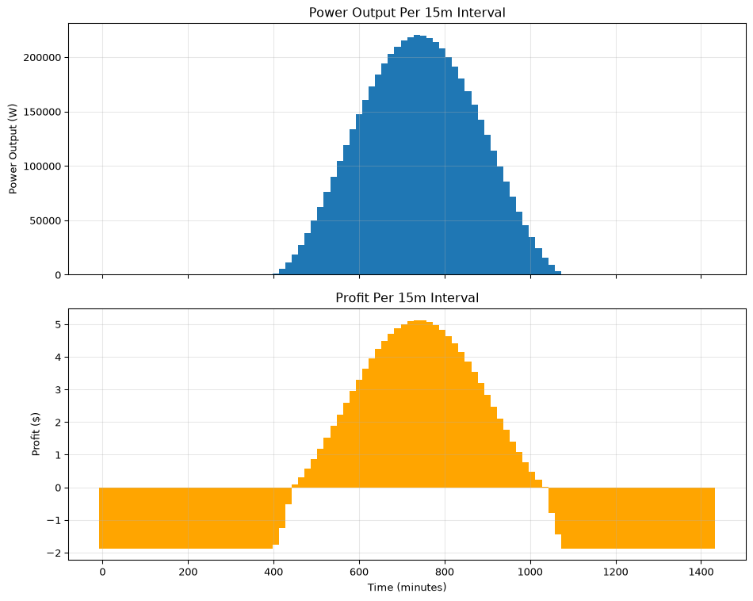

**Note**

The above plot is only displayed when the command `s 11 15` is entered.

Your program should be robust and handle invalid input gracefully. See the example below for how your program should respond to invalid input:

main()

Please enter a command: h

Commands:

- h: Display this help message

- r {filename}: read test data from the specified file

- p: print a table of average power outputs and profits for each month

- s {month} {day}: simulates the solar panel and plots the results

Please enter a command: p

No data loaded. Please load data first using the 'r' command.

Please enter a command: s 11 15

No data loaded. Please load data first using the 'r' command.

Please enter a command: s

No data loaded. Please load data first using the 'r' command.

Please enter a command: k

Please enter a valid command.

Please enter a command: r

Invalid command. Please provide a filename.

Please enter a command: r test/test_data.txt

Please enter a command: s 11 40

Invalid month or day. Please provide a valid month (1-12) and day (1-30).

Please enter a command: s

Invalid command. Please provide a month and day.

Please enter a command: q

Are you sure you want to quit? (y/n): y

**Tip**

You will need to use the functions `read_data()` and `simulate()` from `a1_support.py` to implement the `r` and `s` commands respectively. Read up on how to use these functions in the `a1_support.py` file by carefully reading and understanding its docstrings.

# Writing Your Code

When you submit your assignment to Gradescope you must submit only one code file and **it must be called a1.py**, also ensure that you submit the required `ai_statement.pdf` file (more details below). Do not submit any other code files or it can disrupt the automatic code testing program which will grade your assignments.

# Design

You are expected to use good programming practice in your code, and you must incorporate at least the functions described in the previous part of the assignment sheet.

# Assessment Marking

The maximum achievable mark for this assignment is 10 marks.

## Functionality assessment: 7 marks

The functionality will be marked out of 7. Your assignment will be put through a series of tests and your functionality mark will be automatically generated by the autograder. This grade is NOT overwritten. So if you have a syntax error in your code which causes it to fail all the tests even though the rest of your code is fine, you will still get 0 marks.

Your final functionality mark for the assignment is based on the most recent submission. Note that functionality tests are automated and so string outputs need to exactly match what is expected. **Do not leave it until the last minute** because it generally takes time to get your code to pass the tests.

## Code Style Assessment: 3 marks

The style of your assignment will be assessed by one of the tutors, and you will be marked according to the style rubric below. The style mark will be out of 3.

Your tutor will read your code and record each style violation as either **minor** or **major**, under one of the five categories listed below. Each category is then marked **independently** against the general marking band, and the five categories are **equally weighted**, so each one is worth $3 \div 5 = 0.6$ marks. Your style mark is the sum of the five category marks.

### General marking band

Marking band applied to each category

[output not shown]

**Note**

violations are counted **within** a category, not across the whole assignment. For example, 4 minor formatting violations and 1 minor documentation violation would earn 50% for Formatting (0.3) and 100% for Documentation (0.6), rather than being pooled into a single count of 5.

### Violations

Style violations by category

**Category**

**Minor**

**Major**

**Formatting**

- Line lengths (> 100 chars)
- Vertical / horizontal whitespace
- General readability
- Import statements

–

**Documentation**

- Missing sections for each docstring
- Verbosity of docstrings
- Missing comment per critical code block
- Verbosity per comment
- Unnecessary comments
- Missing docstring

**Identifier Names**

- Non-descriptive identifier names
- 1–2 letter identifier names
- Non `snake_case` identifier names
- Hardcoding literals that appear more than once
- Not using provided constants (i.e. provided in the support file)

**Logic and Modularity**

- Overly nested loops / if statements
- Unnecessary boolean checks (i.e. `if {condition} == True`)
- Fake loops (loops that run only once)
- `for` vs `while`, where one option is clearly better than the other
- Repeated code
- Inappropriate usage of library functions or methods

*Determined on a per case basis — see the note below.*

**Interface & Implementation**

- Variable declared much wider than it is used (i.e. defined at the top of a function but only used inside one branch)
- Unused parameters or leftover variables that are never read
- Relying on a name defined outside the function instead of taking it as a parameter (i.e. a function using a variable defined in `main()`)
- Nested functions (a function defined inside another function)
- Accessing/modifying another class’s private attributes from outside (i.e. `obj._data.append(x)` instead of calling a method)
- Returning a mutable internal attribute so the caller can modify it (i.e. `return self._items` instead of a copy)
- Usage of global variables

**Note**

For the **Logic and Modularity** category, issues are determined to be major or minor on a per case basis by a tutor.

## Assignment Submission

You must submit 2 files to Gradescope: `a1.py` and `ai_statement.pdf`. You will write your code solution in `a1.py` and you will write your usage of ai statement in `ai_statement.pdf`. If you **do not submit** `ai_statement.pdf`, or if the file is **empty**, you will automatically receive **0%** for the assignment, even if your code is perfect.

As such, even if you didn’t use ai for this assignment, you must declare that in your assignment statement. The layout of this statement is up to you, as it is not assessed directly. The following link is an official uq guidance on how to structure your ai statement: [UQ Library](https://guides.library.uq.edu.au/referencing/acknowledging-and-referencing-ai)

You are permitted to submit as many times as necessary to the autograder; only your final submission will be marked. We recommend submitting early and often; submit each completed task to the autograder as soon as it works.

According to the course ECP, late submissions will be penalised by 10% per day for up to 3 days. After 3 days (72 hours), you will recieve a mark of zero. Note that this assignment is not available for an extension, and that there are no exceptions.